# In-Class Exercise 1 Building Elegant Graphics with GGPLOT2

In-Class Exercise 1

Clement Ong https://example.com/norajones (ISSS608 Visual Analytics)https://example.com/spacelysprokets  
2022-01-15

# Install and Loading the Required Libraries

```r
packages = c('tidyverse', 'ggrepel')
for (p in packages){
  if(!require(p,character.only = T)){
    install.packages(p)
  }
  library(p, character.only = T)
}
```

Why Character.only : If you look at help to library (?library) then you got (in Argument section): “package the name of a package, given as a name or literal character string, or a character string, depending on whether character.only is FALSE (default) or TRUE.”

To understand more about the tidyverse : - https://www.tidyverse.org - Example of Reference Docs : https://readr.tidyverse.org

# Import Data into R

Differences between Read.csv and Read_csv - First.Name vs First Name

# Plotting First Chart with GGPLOT2

##### Plotting a grpah in GGPLOT has an order:

- Data : DF (blank face means data loaded)
- Aes : X or Y or BOTH
- Geom : geon_point(), geom_line(), geom_boxplot(),
- Facets : Creating the column of the chart (PANE)
- Statistics : median, average …
- Coordinates : cartesian (x and y axis)
- Theme : Change themes for better colors

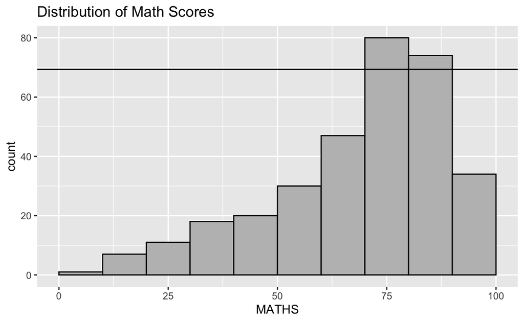

```r
ggplot(exam_data, aes(x=MATHS)) +
  geom_histogram(bins=10,boundary=100, color="black",fill="grey") +
  geom_hline(aes(yintercept = mean(MATHS))) +
  ggtitle("Distribution of Math Scores")
```

Note that for histogram the default is 30 bins. *Make Sure adjust the bins and the Colors*

Notes : - **Boundary is used to ensure the chart does not over run 100** - you can add more like FILL in the ggplot aesthetics which is used for category (Remove the fill in geom object) - color = ‘grey30’ 30 is the intensity of the grey- border of the histogram - boxplot - notch=TRUE - boxplot + point - geom_violin() - as the distribution + geom_boxplot(alpha=0.5) - act as the guiding line - Box plot with summary point, stat_summary(geom=‘point’, fun.y=‘mean’) vs geom_point(stat=‘summary’, fun.y=‘mean’) - leanr to work with facets and coordinates

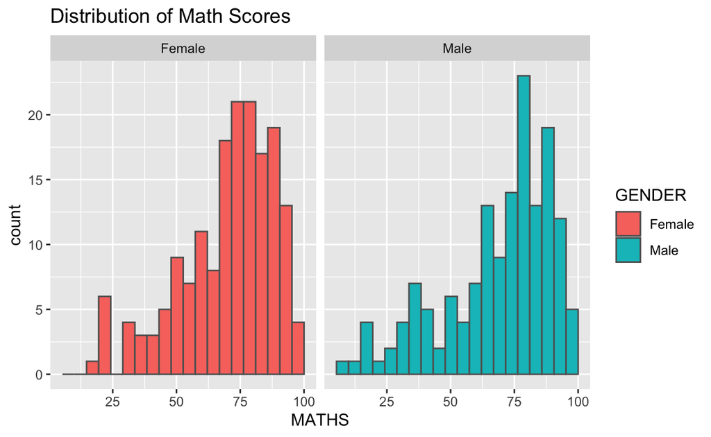

```r
ggplot(exam_data, aes(x=MATHS, fill=GENDER)) +
  geom_histogram(bins=20,boundary=100, color="grey38") +
  facet_wrap(~GENDER) +
  ggtitle("Distribution of Math Scores")
```